# aula_1_intro

[figure not shown]

[figure not shown]

Escola Superior de Agricultura “Luiz de Queiroz”

Departamento de Genética

LGN 313 - Melhoramento Genético

**Introdução ao melhoramento genético**

Prof. Saulo Chaves

Piracicaba, São Paulo, Brasil

**Condições para aprovação**

“*Será aprovado, com direito aos créditos correspondentes, o aluno que obtiver nota final igual ou superior a cinco e tenha, no mínimo, setenta por cento de frequência na disciplina.*” (Art. 84 do Regimento Geral da USP)

## Conteúdo de hoje

1. Motivação e contextualização
2. Conceituação
3. O melhoramento e a sociedade
4. Prática

# Contextualização

## Motivação

Quais os papéis do engenheiro agrônomo na sociedade?

Como o engenheiro agrônomo contribui para a segurança alimentar?

O que pode colocar a segurança alimentar em risco?

## Crescente da população

[figure not shown]

[Population matters](https://populationmatters.org/)

## Limite da fronteira agrícola

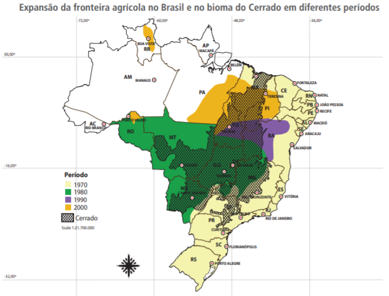

[José Eustáquio Ribeiro Vieira Filho, IPEA (2016)](https://geografiavisual.com.br/fotografias/a-relacao-entre-a-fronteira-agricola-e-o-arco-do-desmatamento-na-amazonia)

## Teoria malthusiana

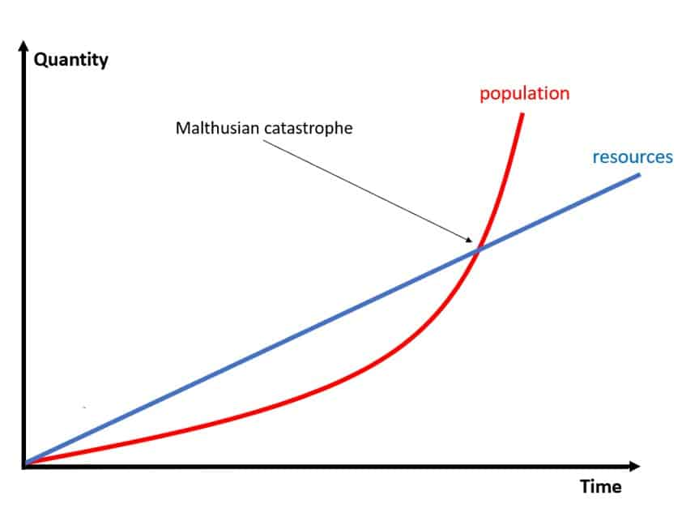

[Gavin Chau](https://www.bluewealth.com.au/the-research-blog/thanos-malthusian-dilemma/)

Estamos lidando com isso, mas até quando e a que custo? 🤔

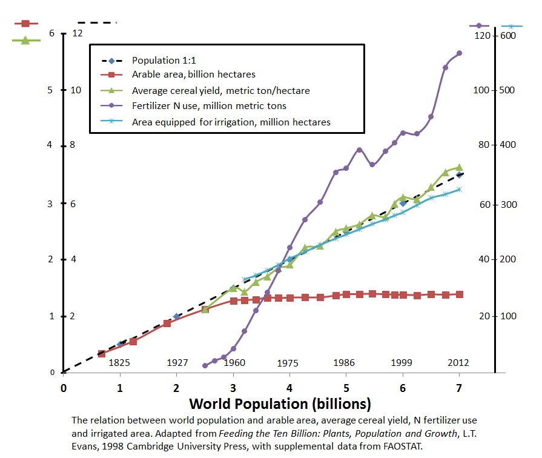

[GMO school](https://gmoschooldotcom.wordpress.com/2015/05/14/population-resources-and-food-production/)

## Mudanças climáticas

[figure not shown]

[Ed Hawkins](https://ed-hawkins.github.io/climate-visuals/spirals.html)

## Fome explícita e oculta

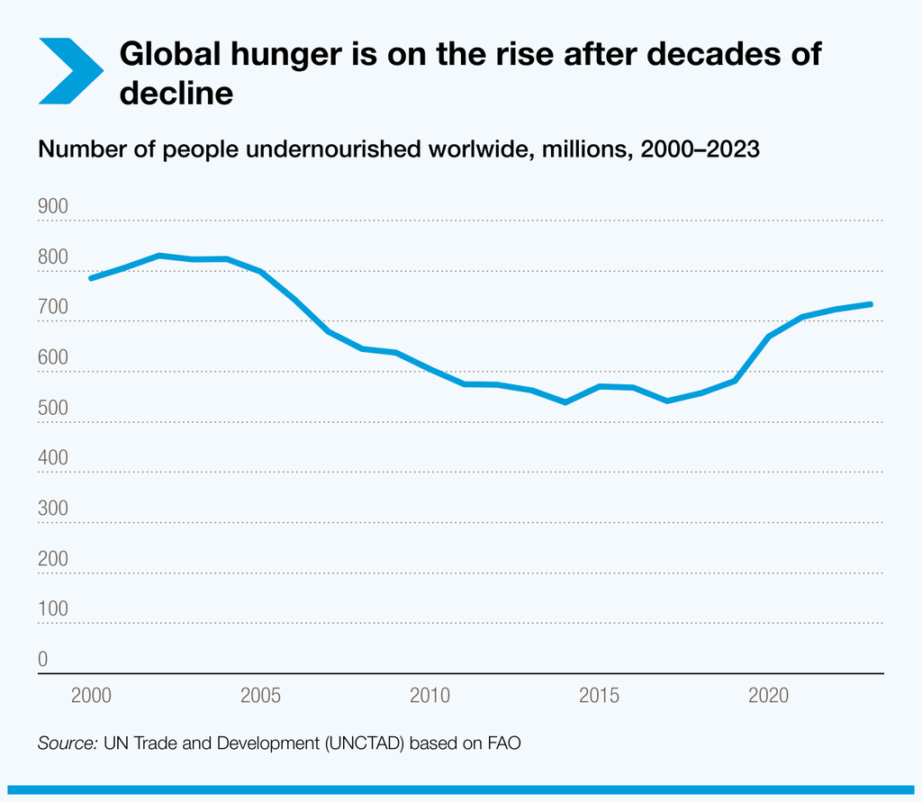

[ONU (2024)](https://unctad.org/news/733-million-people-face-chronic-hunger-heres-how-trade-can-help)

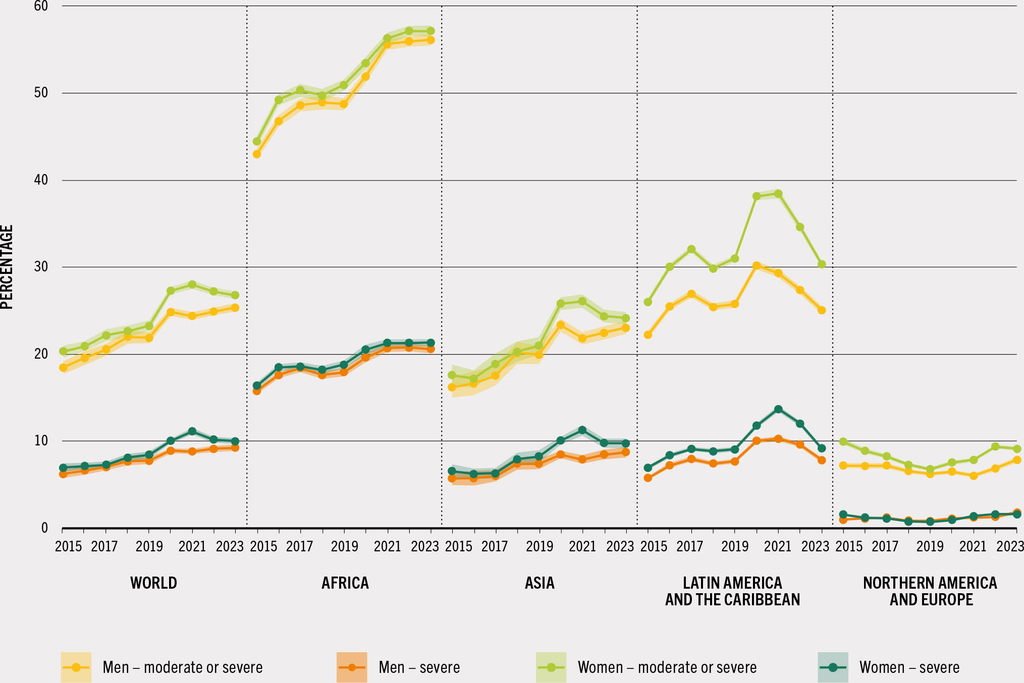

[FAO (2024)](https://openknowledge.fao.org/server/api/core/bitstreams/39dbc6d1-58eb-4aac-bd8a-47a8a2c07c67/content/state-food-security-and-nutrition-2024/ending-hunger-food-security.html#gsc.tab=0)

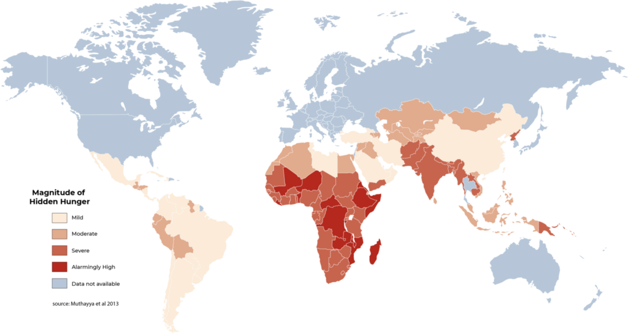

[Harvest Plus](https://www.harvestplus.org/)

- Uma a cada 4 pessoas sofrem de fome oculta

# Melhoramento genético vegetal

A arte, a ciência e o negócio de alteração genética das plantas para benefício do homem.

- Aumentar a produtividade em uma mesma área
- Diminuir a necessidade de insumos
- Aumentar a resistência a doenças
- Aumentar a qualidade dos alimentos (biofortificação)
- Produzir **cultivares** por meio de repetidos ciclos de cruzamentos e seleção

O melhoramento vegetal é a forma mais ecologicamente correta de aumentar a produção de alimentos (e outras matérias-primas de base agropecuária), com a adaptação da planta ao ambiente, e não do ambiente a planta.

# O melhoramento como *Arte*

## Arte (no dicionário)

- *“Conjunto de meios e procedimentos através dos quais é possível a obtenção de finalidades práticas ou a produção de objetos; técnica.”*
- *“Habilidade ou disposição dirigida para a execução de uma finalidade prática ou teórica, realizada de forma consciente, controlada e racional.”*
- *“Talento, contribuição própria da inteligência e da sensibilidade de um artista.”*

> A história da agricultura e do melhoramento se confundem $\rightarrow$ domesticação
- Do teosinto ao milho

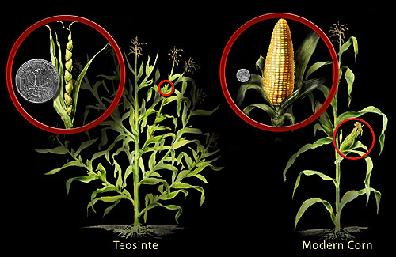

Nicolle Rager Fuller

> A história da agricultura e do melhoramento se confundem $\rightarrow$ domesticação
- Tomates silvestres vs tomate de mesa

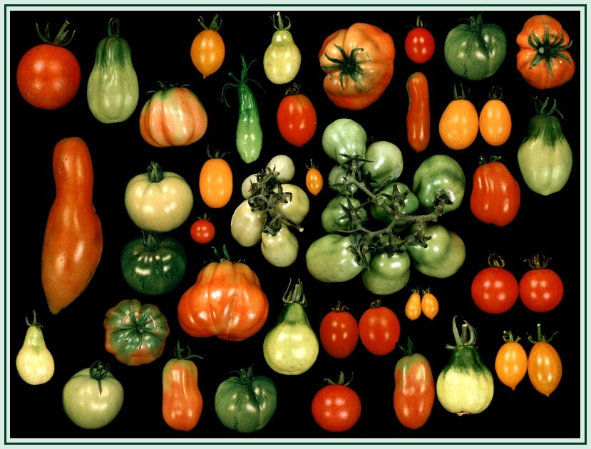

[IT News & Events](https://news.iu.edu/it/live/news/31886-collaboration-between-biology-and-research)

> A história da agricultura e do melhoramento se confundem $\rightarrow$ domesticação
- Maçãs silvestres vs Maçãs comerciais

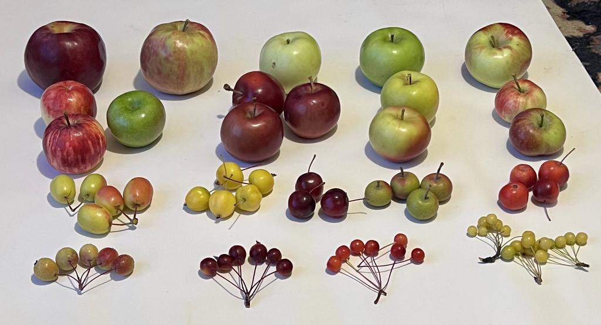

[Awais Khan](https://www.linkedin.com/posts/awais-khan-40826b36_apples-geneticdiversity-cropwildrelatives-activity-7267715909740294144-7XV7)

> A história da agricultura e do melhoramento se confundem $\rightarrow$ domesticação
- Bananas e platanos com sementes

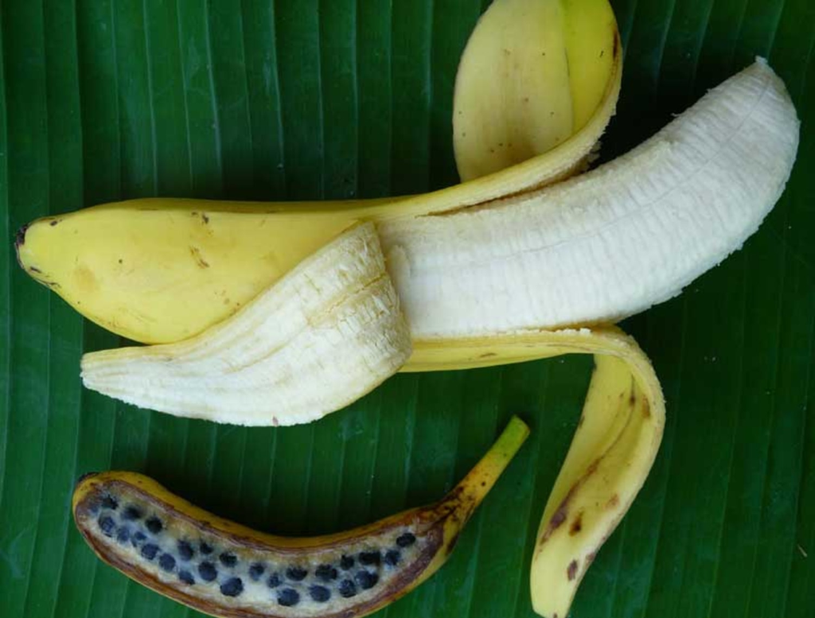

[Angélique D'Hont](https://g1.globo.com/ciencia-e-saude/noticia/2012/07/pesquisa-revela-genoma-da-bananeira.html)

## Variedades crioulas

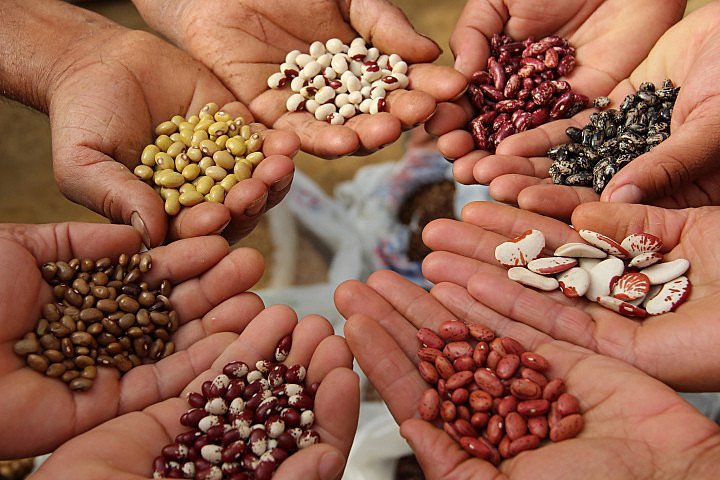

[Divulgação/MPA](https://www.brasildefato.com.br/podcast/momento-agroecologico/2017/08/01/sementes-crioulas-a-heranca-da-sabedoria-ancestral-na-agricultura/)

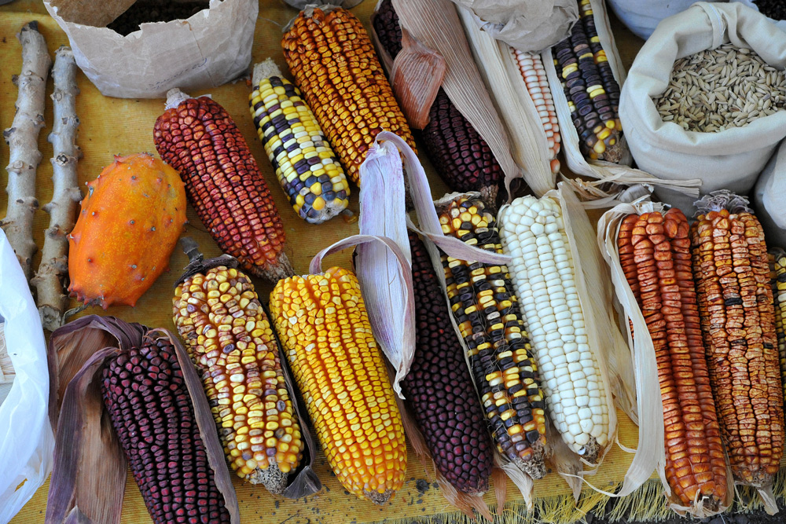

[Cecília Bastos/USP Imagens](https://imagens.usp.br/editorias/natureza-categorias/sementes/attachment/troca-de-sementes-no-rio20-5/)

- Melhoramento empírico
- Conhecimento popular
- Grande importância científica

# O melhoramento como *Ciência*

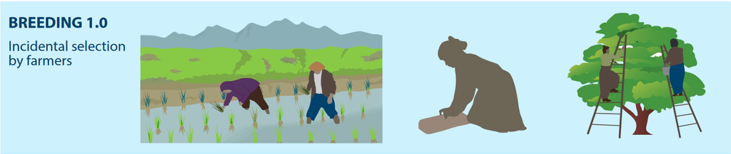

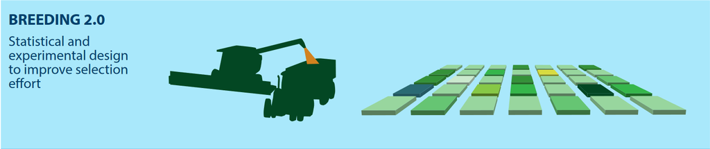

[Wallace et al. (2018)](https://www.annualreviews.org/content/journals/10.1146/annurev-genet-120116-024846)

## Mudança de paradigma

**Genética mendeliana**

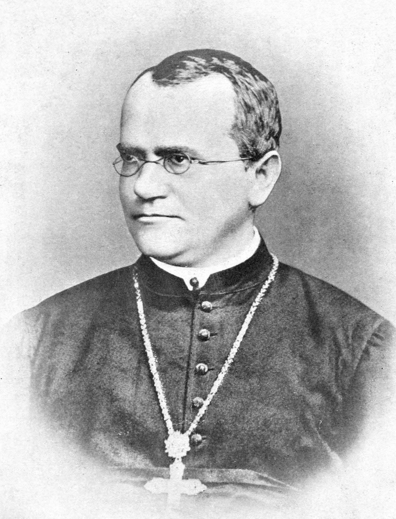

[William Bateson](https://pt.wikipedia.org/wiki/Gregor_Mendel)

**Estatística e experimentação**

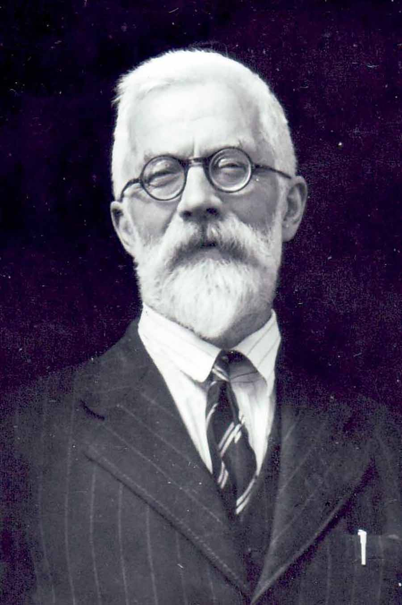

[University of Adelaide archive](https://set.adelaide.edu.au/events/list/sir-ronald-fisher-lecture)

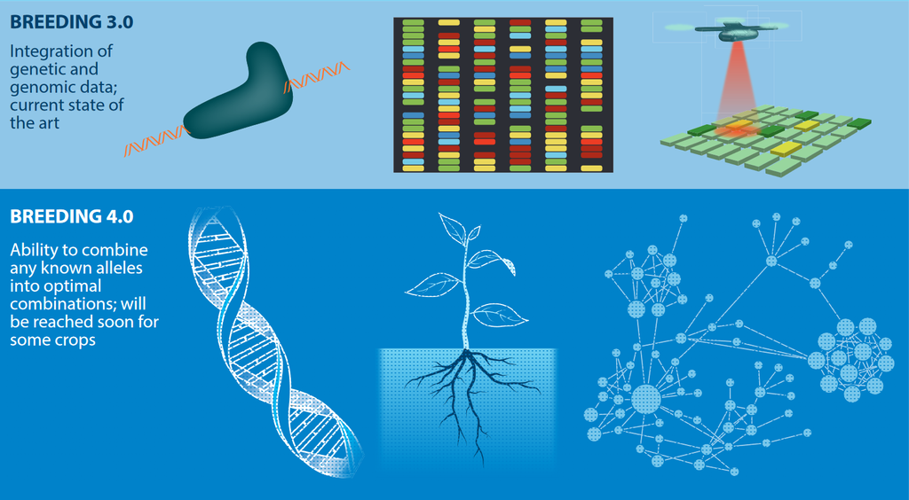

[Wallace et al. (2018)](https://www.annualreviews.org/content/journals/10.1146/annurev-genet-120116-024846)

**Não há melhoramento vegetal sem:**

- Método científico
- Interdisciplinariedade
- Trabalho em equipe

**Não há um único caminho para o sucesso**

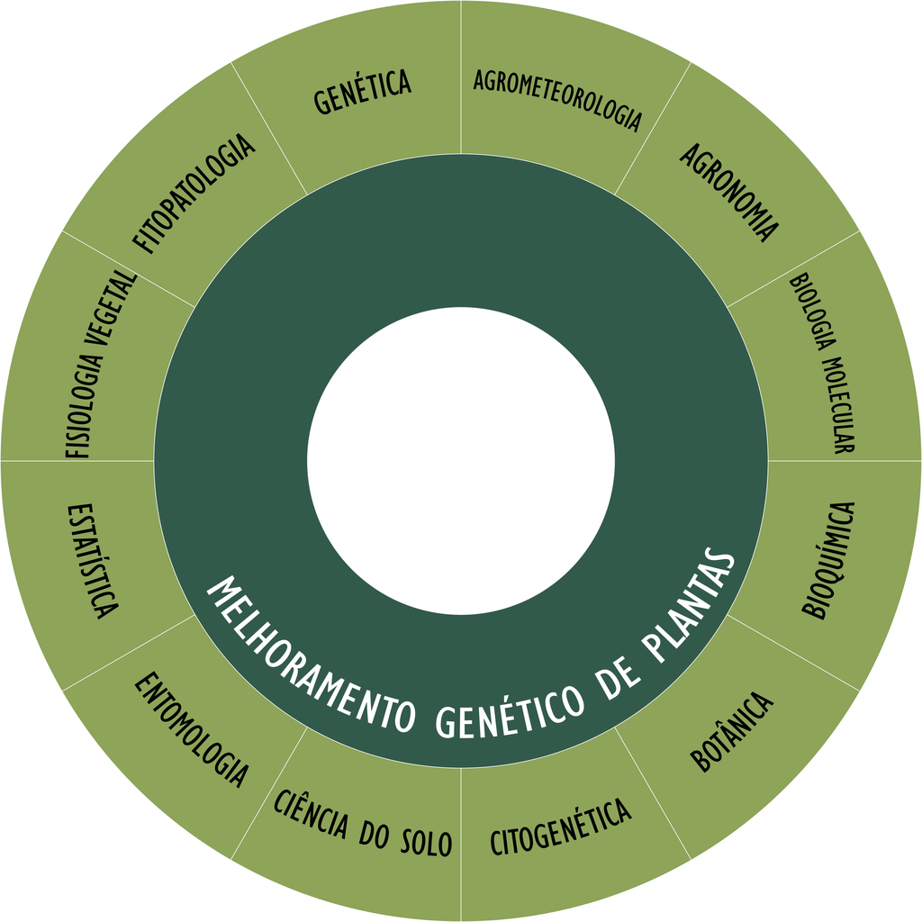

# O melhoramento como *Negócio*

## Indústria de sementes agronômicas

[figure not shown]

[Doriane (2024)](https://www.doriane.com/blog/top-seed-companies)

## Empresas de base florestal

[figure not shown]

[SIF](https://sif.org.br/2020/04/o-manejo-sustentavel-da-agua-por-prof-herly-dias/)

## Melhoramento de espécies estratégicas

- Instituições públicas de pesquisa: Embrapa, IAC, etc.
- Universidades públicas
- Exemplo: RIDESA (cana-de-açúcar) $\rightarrow$ clones RD

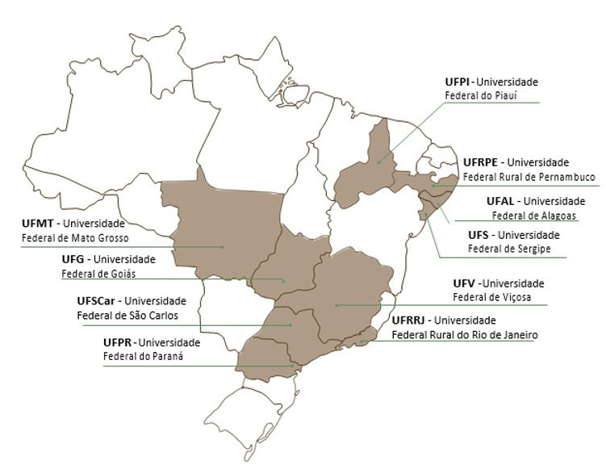

[RIDESA](https://www.ridesaufscar.com.br/historico)

## Programa de pós-graduação em Genética e Melhoramento - USP/ESALQ

# O melhoramento e a sociedade

## Revolução verde

- Conjunto de medidas adotadas para elevar a produção de alimentos
  - Fertilizantes e defensivos
  - Mecanização e irrigação
  - **Sementes melhoradas**
- Impactos em países em desenvolvimento
  - México, Índia, Filipinas, China e Brasil

## “Pais” da revolução verde

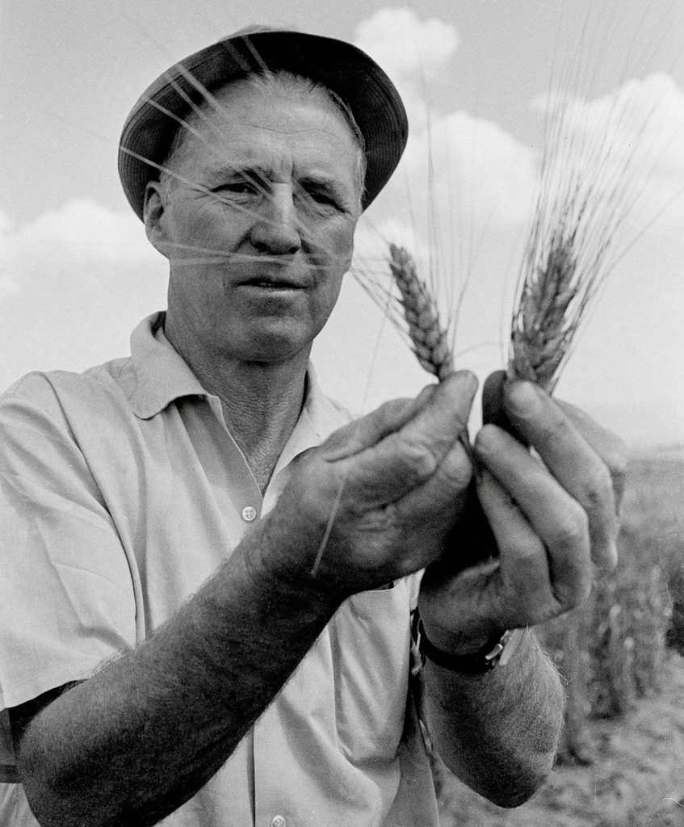

[Norman Bourlag (Nobel da Paz, 1970): AP Images](https://achievement.org/achiever/norman-e-borlaug/)

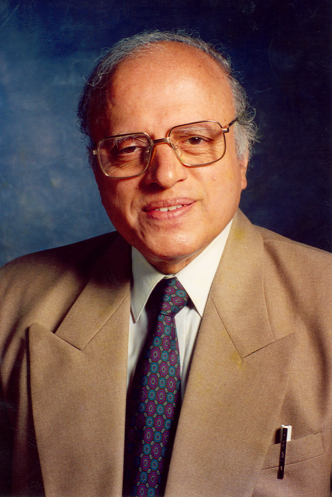

[M. S. Swaminathan (India): IANS Photo](https://www.morungexpress.com/m-s-swaminathan-a-light-that-shone-was-no-ordinary-light)

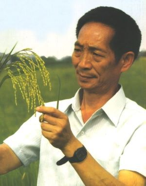

[Yuan Longping (China): World Food Prize](https://www.worldfoodprize.org/en/laureates/20002009_laureates/2004_jones_and_yuan/)

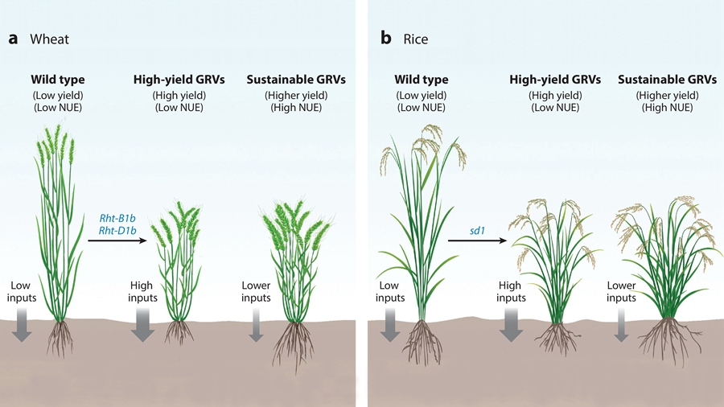

[Liu et al. (2022)](https://www.annualreviews.org/content/journals/10.1146/annurev-arplant-070121-015752)

Cultivares anãs (resistentes ao acamamento e ótimas para mecanização) e precoces (possibilidade de mais de uma safra)

## Batata-doce na África

- Combate a fome oculta
- Deficiência de vitamina A: cegueira e baixa imunidade
- Batata-doce: base alimentar em muitos países da África
- Cultivares com polpa branca e laranja (beta-caroteno)

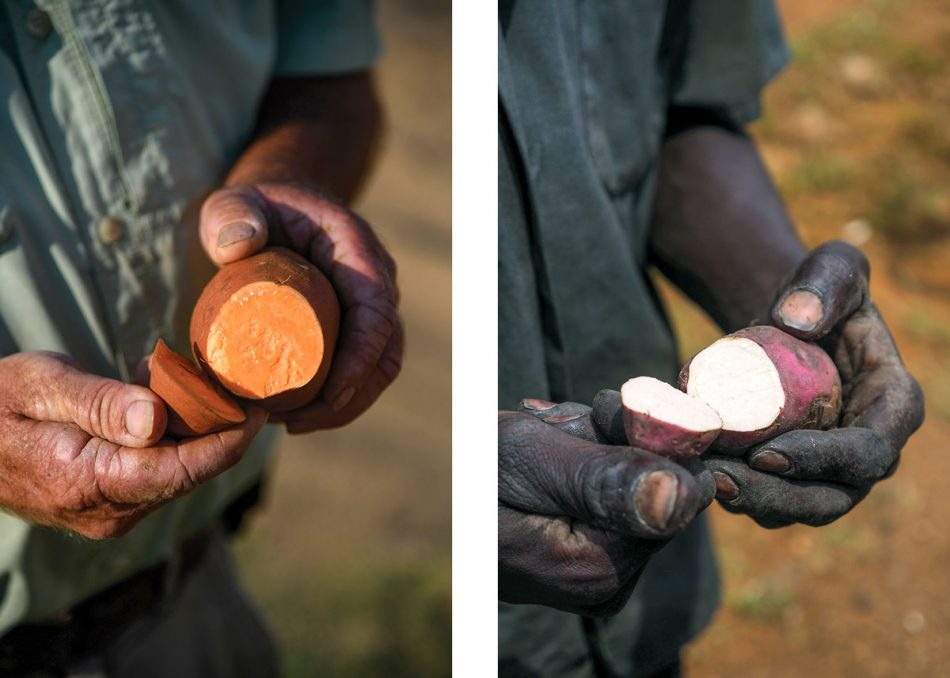

[Marc Hall](https://cals.ncsu.edu/news/nc-state-researchers-continue-improving-sweetpotatoes-for-africa/)

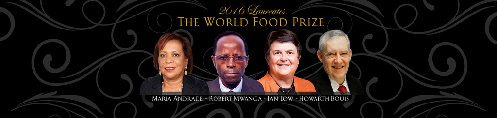

[CIP](https://cipotato.org/blog/cip-sweetpotato-scientists-awarded-prestigious-world-food-prize/)

- Seleção de variedades com polpa alaranjada
- Re-educação da população (consumidores e produtores)
- Busca de recursos para uma espécie órfã
- Resultado: adoção da batata-doce melhorada por quase 7 milhões de pequenas propriedades (África e sul asiático)

“Uma batata-doce biofortificada de polpa alaranjada pode fornecer a necessidade diária de vitamina A de uma criança”

## Leitura sugerida 📔

- Capítulos 1 e 2 do livro “Melhoramento de Plantas” (Aluízio Borém, Glauco Miranda e Roberto Fritsche-Neto)
- Capítulo 1 do livro “Principles of Plant Genetics and Breeding” (George Acquaah)
- [Melhoramento genético de plantas: trabalhando para produzir mais, melhor e de forma sustentável](https://croplifebrasil.org/melhoramento-genetico-de-plantas-trabalhando-para-produzir-mais-melhor-e-de-forma-sustentavel/)
- [The facist green revolution](https://nph.onlinelibrary.wiley.com/doi/full/10.1002/ppp3.10386)
- [Histórico da RIDESA](https://www.ridesa.com.br/historia)

## Vídeos interessantes 💻

- [2016 Laureates: Maria Andrade, Howarth Bouis, Jan Low and Robert Mwanga](https://www.youtube.com/watch?v=iyUM0XQdRHs&ab_channel=WorldFoodPrizeFoundation)
- [“India’s Green Revolution: More Harm Than Good” by Vandana Shiva](https://www.youtube.com/watch?v=nze2K2hgTqY&ab_channel=GlobalInstituteofSustainabilityandInnovation)

[figure not shown]

[figure not shown]

Grato!